# Homework #3: Submission

Christian Conroy

In the provided `.Rmd` template, write your code and commentary. Choose two easy tasks (0.5 points per), the one medium task (1 point), and one of the hard tasks (3 points per). Delete subtasks that you did not choose to do.

```r
#Load in data

  github.url <- "https://github.com/GeorgetownMcCourt/data-science/blob/master/homework_data/"
  file.url <- "wmata_2016to2017.csv.zip?raw=true"
  wmata <- import(paste0(github.url, file.url))
```

## (1) Warm up

- Check the structure and formats of the data.
- Create a date-time object by applying `strptime()` to a concatenation of the `date` and `time` fields. For reference, take a look at the date-time documentation ([link](https://stat.ethz.ch/R-manual/R-devel/library/base/html/strptime.html)).
- Also set up a date object using `as.Date`.

```r
str(wmata)
```

```
## 'data.frame':    7928 obs. of  23 variables:
##  $ date                   : chr  "July 30, 2016" "July 30, 2016" "July 30, 2016" "July 30, 2016" ...
##  $ dayofweek              : chr  "Saturday" "Saturday" "Saturday" "Saturday" ...
##  $ link                   : chr  "https://www.wmata.com/service/daily-report/daily-service-report.cfm?id=20160801043823" "https://www.wmata.com/service/daily-report/daily-service-report.cfm?id=20160801043823" "https://www.wmata.com/service/daily-report/daily-service-report.cfm?id=20160801043823" …
##  $ line                   : chr  "Red" "Orange" "Red" "Yellow" ...
##  $ direction              : chr  "Glenmont" "Vienna" "Glenmont" "Huntington" ...
##  $ delay                  : int  7 9 10 5 7 6 NA 23 6 8 ...
##  $ time.occur             : chr  "11:27AM" "12:49PM" "1:57PM" "3:51PM" ...
##  $ text                   : chr  "Â 11:27 am A Glenmont-bound Red Line train at Shady Grove was delayed 7 minutes due to an unauthorized person on the track.Â " "12:49 pm A Vienna-bound Orange Line train at Smithsonian was offloaded due to a door problem. Passengers experi"| __truncated__ "1:57 p…
##  $ reason.spacing         : int  0 0 0 0 0 0 0 0 0 0 ...
##  $ reason.medical         : int  0 0 0 0 0 0 0 0 0 0 ...
##  $ reason.police          : int  0 0 0 0 0 0 0 0 0 0 ...
##  $ reason.brake           : int  0 0 0 0 0 0 0 1 1 0 ...
##  $ reason.equipment       : int  0 0 0 0 0 0 0 0 0 0 ...
##  $ reason.door            : int  0 1 0 1 0 0 0 0 0 1 ...
##  $ reason.operational     : int  0 0 0 0 0 1 0 0 0 0 ...
##  $ reason.disabled.train  : int  0 0 0 0 0 0 0 0 0 0 ...
##  $ reason.arcing.insulator: int  0 0 0 0 0 0 0 0 0 0 ...
##  $ outcome.offboard       : int  0 0 0 0 0 0 0 0 0 0 ...
##  $ outcome.singletrack    : int  0 0 0 0 0 0 0 1 0 0 ...
##  $ outcome.shuttle        : int  0 0 0 0 0 0 1 0 0 0 ...
##  $ in.station             : chr  "Shady Grove" "Smithsonian" "Wheaton" "L'Enfant Plaza" ...
##  $ bw.station.1           : chr  "" "" "" "" ...
##  $ bw.station.2           : chr  "" "" "" "" ...
```

```r
timedate <- strptime((paste(wmata$date, wmata$time.occur)), '%B %d, %Y %H:%M%p')
date <- as.Date(wmata$date, '%B %d, %Y')
```

## (2) Easy

1. *When are the peak hours for delays?* *Expected outcome*: A bar plot the total number of delays for each hour of the day in `time.occur`.

NOT CHOOSING AS ONE OF CHOSEN TASKS FOR EASY SECTION. Challenge getting R to recognize AM/PM distinction. It was only recognizing 12PM and conflating all others for AM.

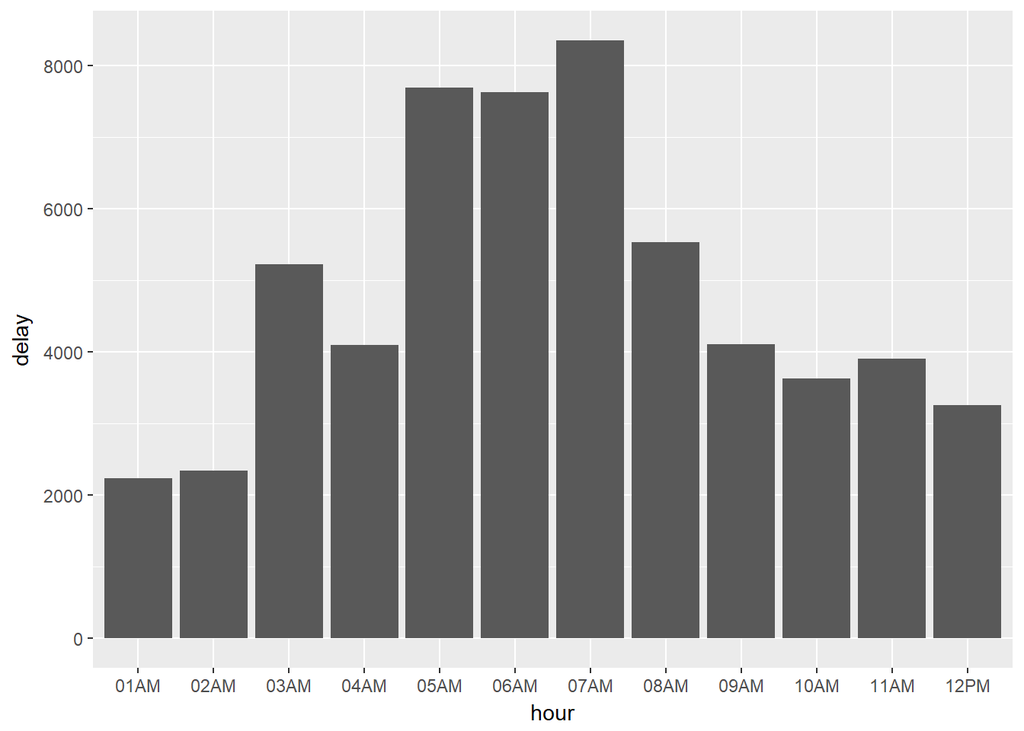

2. *Which stations are associated with the most delays?* *Expected outcome*: A bar plot the total number of delays for `in.station`.

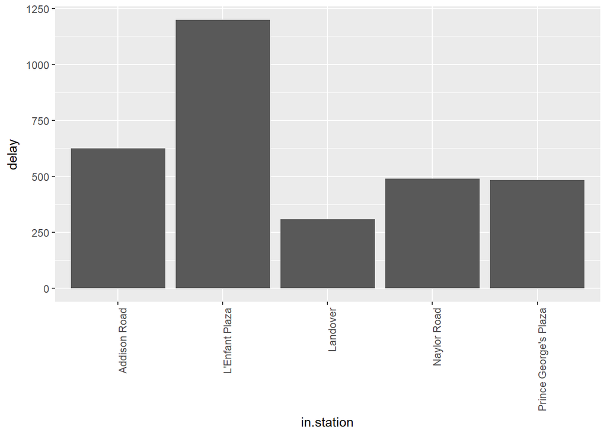

```r
stadelays <- wmata$in.station[order(wmata$delay, decreasing = TRUE)]

ggplot(data=subset(wmata, in.station %in% stadelays [1:5]), aes(x=in.station, y=delay)) + geom_bar(stat="identity") + theme(axis.text.x = element_text(angle = 90, hjust = 1))
```

3. *Which train lines are associated with the most delays?* *Expected outcome*: A bar plot the total number of delays for `line`.

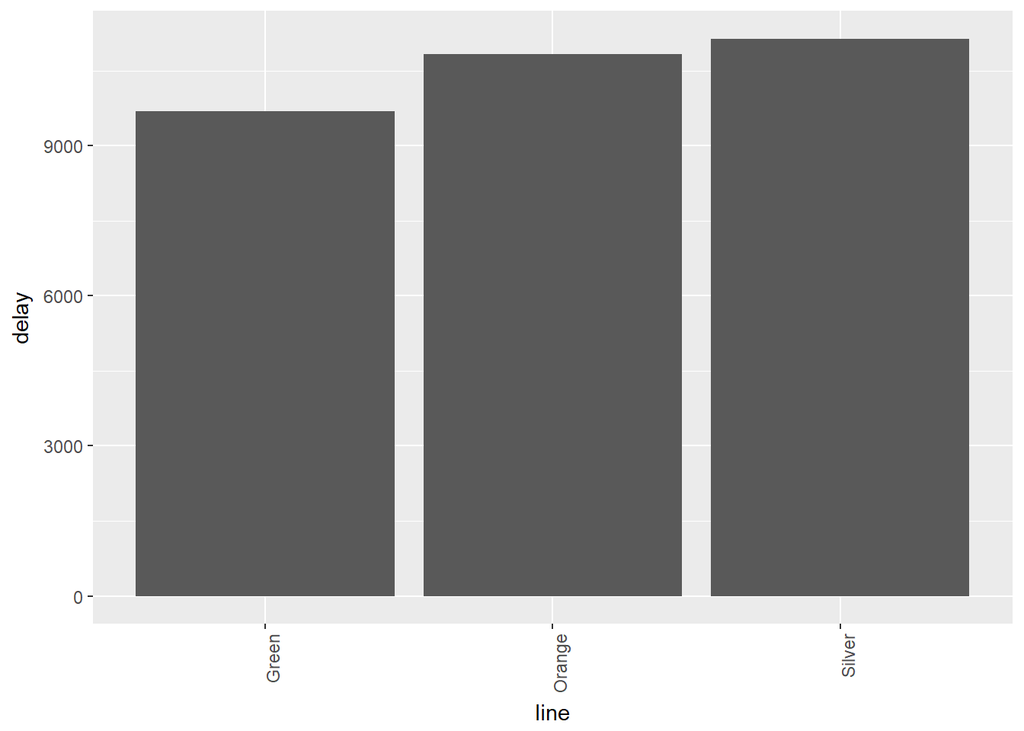

```r
linedelays <- wmata$line[order(wmata$delay, decreasing = TRUE)]

ggplot(data=subset(wmata, line %in% linedelays [1:5]), aes(x=line, y=delay)) + geom_bar(stat="identity") + theme(axis.text.x = element_text(angle = 90, hjust = 1))
```

It looks like the Silver line is associated with the most delays, followed by the Orange and Green lines.

4. *What does the time series look like?* *Expected outcome*: A line plot the total number of delays for `line`.

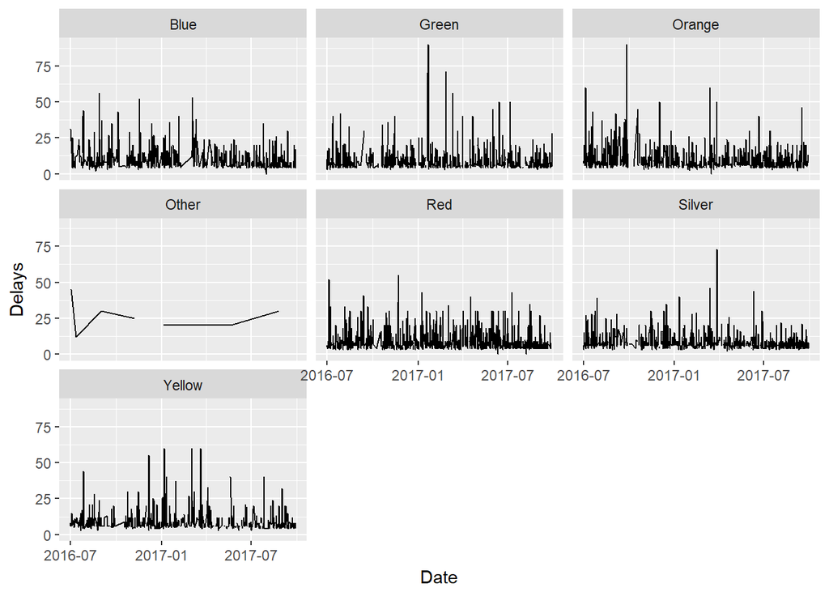

```r
wmata$date2 <- as.Date(wmata$date, '%B %d, %Y')
ggplot(wmata, aes(date2, delay)) + geom_line() + xlab("Date") + ylab("Delays") + facet_wrap(~line)
```

## (3) Medium

1. *What is the relative importance of each reason for delays*? *Expected outcome*: Process the data into the appropriate form so that the `wordcloud` package can scale each `reason.` based on its frequency. An example wordcloud can be found [here](https://www.wordclouds.com/).

Counting the reason frequency.

```r
reasoncounts <- as.data.frame(ldply(wmata[,10:17],function(x) t(rbind(names(table(x)),table(x)))))
reasoncounts  <- subset(reasoncounts,`1` == 1)
reasoncounts$`1` <- NULL
names(reasoncounts) <- c("reason", "count")
reasoncounts$reason <- sub("reason.","", reasoncounts$reason)
reasoncounts$count <- as.numeric(reasoncounts$count)
```

Developing the wordcloud

```
##              reason count
## 10             door    14
## 16 arcing.insulator     8
## 8         equipment     6
## 4            police     5
## 2           medical     4
```

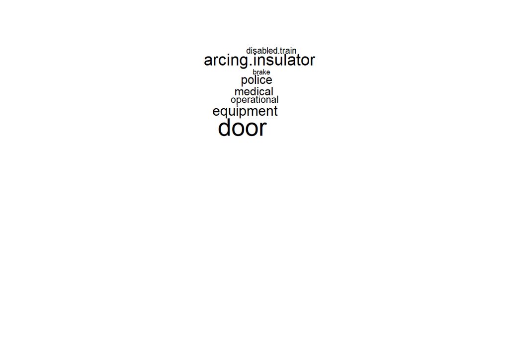

```r
set.seed(123)
par(mfrow=c(2,1))
reasoncounts <- reasoncounts[order(-reasoncounts$count),]
wordcloud(reasoncounts$reason, reasoncounts$count, fixed.asp = TRUE, rot.per = .15, c(2,.5), FALSE)
head(reasoncounts[order(reasoncounts$count,decreasing = TRUE), ], 5)
```

# Door looks to be the most important word.

## (4) Hard[er]

1. *Which metro line has the highest chance of having a delay longer than 10 minutes? Which has the lowest chance?*

Creating the function to show the Survival Curves for each line

```r
linesurvcurve <- function (line) {
wmatasub <- wmata[wmata$line==line,]
delbydate <- aggregate(delay ~ date2, data = wmatasub, sum)
delbydate <- delbydate[order(delbydate$date2),]
delbadd <- data.frame(date2=as.POSIXct(Sys.time(), origin="1970-01-01"), delay = 0)
delbydate <- rbind(delbadd, delbydate)
delbydate$time <- rep(0:(length(delbydate$date2)-1))
delbydate <- subset(delbydate, delbydate$time <= 15)

delbydate$diff <- sum(delbydate$delay)
n <- nrow(delbydate)
if (n > 1) for(i in 2:n) delbydate$diff[i] <- (delbydate$diff[i-1] - delbydate$delay[i-1])

delbydate$dn <- delbydate$delay/delbydate$diff
delbydate$dnsub1 <- 1-delbydate$dn

delbydate$s <- delbydate$dnsub1[1]
delbydate$s[2] <- delbydate$dnsub1[2]
n <- nrow(delbydate)
if (n > 1) for(i in 3:n) delbydate$s[i] <- prod(delbydate$dnsub1[1:i])

p <- ggplot(delbydate, aes(time, s)) + geom_line() + xlab("time t") + ylab("s(probability of lasting beyond time t")
return(p)
}
```

Creating the function to get the highest probability at time t = 10

```r
linesprob10 <- function (line) {
  wmatasub <- wmata[wmata$line==line,]
  delbydate <- aggregate(delay ~ date2, data = wmatasub, sum)
  delbydate <- delbydate[order(delbydate$date2),]
  delbadd <- data.frame(date2=as.POSIXct(Sys.time(), origin="1970-01-01"), delay = 0)
  delbydate <- rbind(delbadd, delbydate)
  delbydate$time <- rep(0:(length(delbydate$date2)-1))
  delbydate <- subset(delbydate, delbydate$time <= 15)

  delbydate$diff <- sum(delbydate$delay)
  n <- nrow(delbydate)
  if (n > 1) for(i in 2:n) delbydate$diff[i] <- (delbydate$diff[i-1] - delbydate$delay[i-1])

  delbydate$dn <- delbydate$delay/delbydate$diff
  delbydate$dnsub1 <- 1-delbydate$dn

  delbydate$s <- delbydate$dnsub1[1]
  delbydate$s[2] <- delbydate$dnsub1[2]
  n <- nrow(delbydate)
  if (n > 1) for(i in 3:n) delbydate$s[i] <- prod(delbydate$dnsub1[1:i])

  q <- delbydate$s[delbydate$time == 10]
  return(q)
}
```

Getting the max probability at time t=10

```r
max(c(linesprob10('Blue'), linesprob10('Green'), linesprob10('Orange'), linesprob10('Red'), linesprob10('Silver'), linesprob10('Yellow')))
```

```
## [1] 0.5184275
```

```r
linesprob10('Blue')
```

```
## [1] 0.5184275
```

The highest probability at time t = 10 is blue.

Plotting the survival curves.

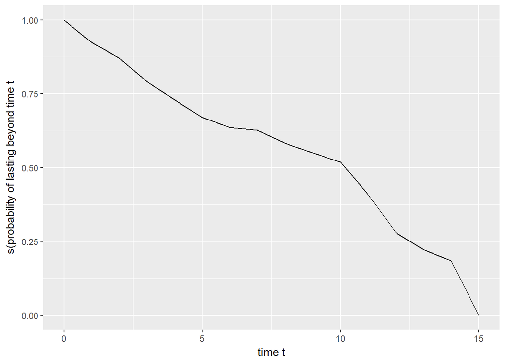

```r
linesurvcurve('Blue')
```

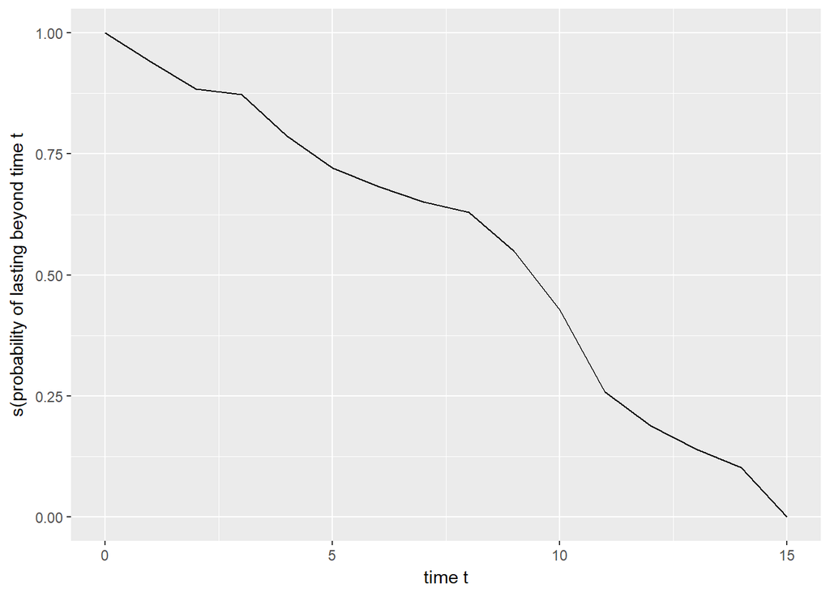

```r
linesurvcurve('Green')
```

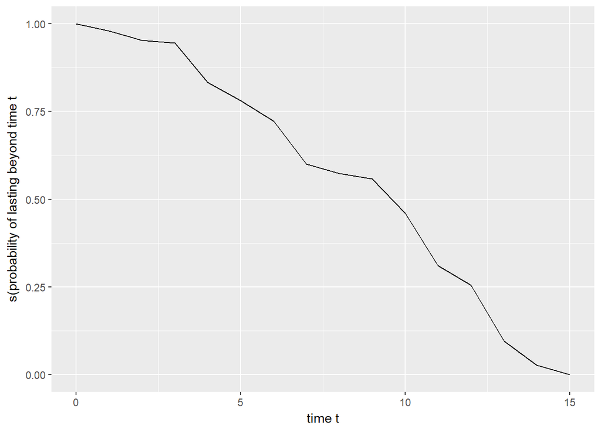

```r
linesurvcurve('Orange')
```

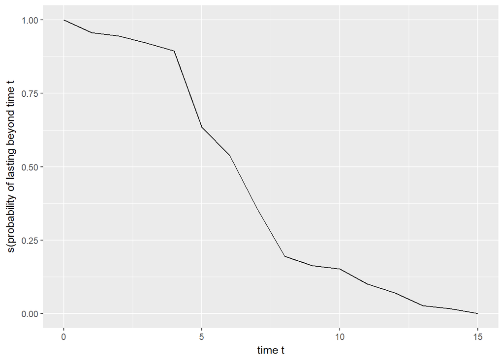

```r
linesurvcurve('Red')
```

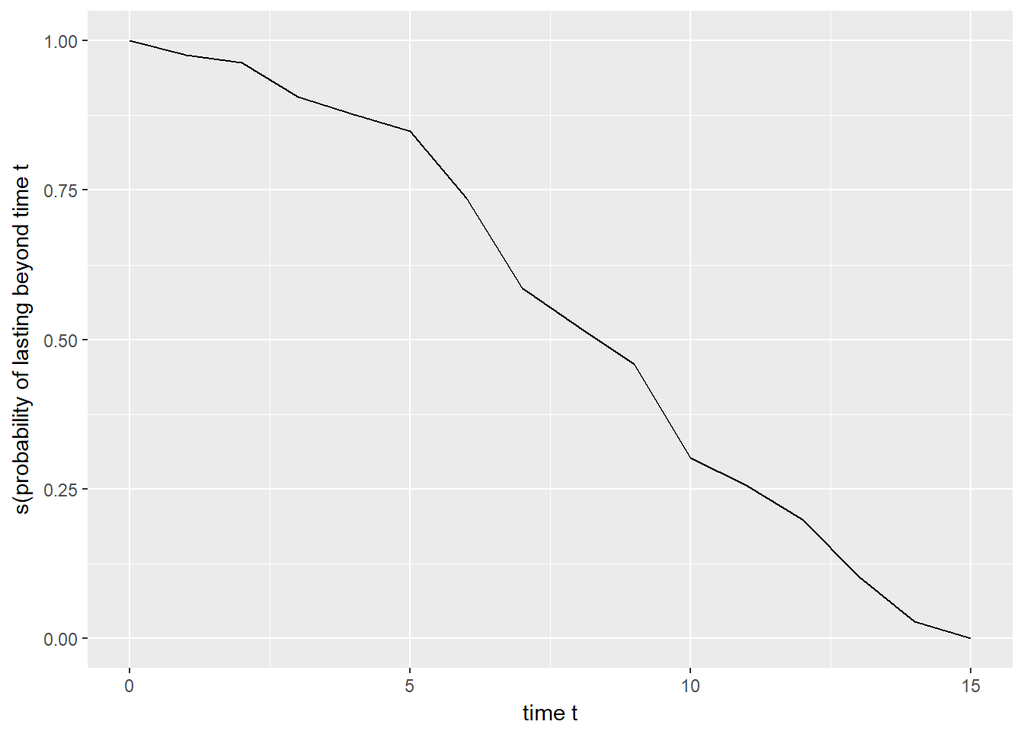

```r
linesurvcurve('Silver')
```

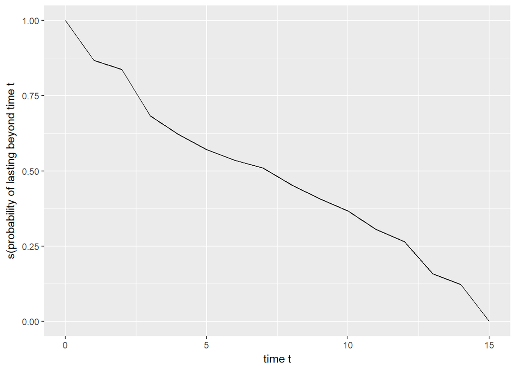

```r
linesurvcurve('Yellow')
```

2. *Which terms are the most important terms in the advisory text when comparing the Red Line to the Silver Line?* *Expected outcome*: Process the `text` field into unigrams. Remove stop words. Calculate TFIDF using Red and Silver Lines as documents. Using the `wordcloud` package, plot terms in two separate wordclouds.

Organizing the data frame and cleaning up the text

```r
List <- strsplit(wmata$text, " ")
advisory <- data.frame(Id=rep(wmata$line, sapply(List, length)), Words=unlist(List))
advisory <- advisory[advisory$Id == "Red" | advisory$Id == "Silver",]
advisory <- advisory[-grep("[[:digit:]]", advisory$Words),]
advisory$Words <- gsub("[[:punct:]]","", advisory$Words)
advisory$Words <- gsub("[^[:graph:]]", "", advisory$Words)
advisory$Words <- gsub("Â", "", advisory$Words)
```

Removing Stop Words

```r
#Get stopwords
stop1 <- read_html("http://www.lextek.com/manuals/onix/stopwords1.html")

stopwords <- stop1 %>%
  html_nodes("pre") %>%
  html_text()

stoplist <- unlist(strsplit(stopwords,"\n"))
stoplist <- stoplist[stoplist!="" & nchar(stoplist)>1]
stoplist <- stoplist[4:length(stoplist)]

#Remove stopwrods
advisory <- advisory[!(advisory$Words %in% stoplist),]
```

Aggregating to get counts of number of times a word shows up and naming columns.

```r
countsadv <- aggregate(advisory$Words, by=list(advisory$Id, advisory$Words), FUN=length)
colnames(countsadv) <- c("line", "word","freq")
```

TFIDF Function

```r
tfidf <- function(df, count.field, term, document){

  df <- df[,c(count.field, term, document)]
  colnames(df) <- c("count","term","doc")

  #Total frequency of terms
  df$tot_freq <- sum(df$count)

  #Number of documents
  df$num_docs <- length(unique(df$doc))

  #Number of documents with a given term
  datatemp <- df[!duplicated(df[,c("doc", "term")]),]
  num_doc_term <- aggregate(datatemp$term,
                            by = list(term = datatemp$term),
                            FUN = length)
  colnames(num_doc_term)[2] <- "num_doc_term"

  #merge
  df <- merge(df, num_doc_term, by = "term", all.x = T)

  #compute
  df$tfidf <- (df$count/df$tot_freq) * log(df$num_docs / df$num_doc_term)
  df <- df[, c("count","term", "doc", "tfidf")]
  colnames(df) <- c(count.field, term, document, "tfidf")
  return(df)
}
```

Apply TFIDF Function and Subsetting

```r
p2forwordc <- as.data.frame(tfidf(countsadv, count.field = "freq", term = "word", document = "line"))
p2forwordc <- subset(p2forwordc, p2forwordc$tfidf>0)
```

Final Wordcloud and Listing of Ranked Term Importance

```
##     freq               word   line        tfidf
## 164  764         Grovebound    Red 0.0106599389
## 111  639          Eastbound Silver 0.0089158390
## 154  619      Glenmontbound    Red 0.0086367830
## 158  260     Grosvenorbound    Red 0.0036277279
## 153  163           Glenmont    Red 0.0022743063
## 197   63             McLean Silver 0.0008790264
## 36    41         BallstonMU Silver 0.0005720648
## 223   36 NoMaGallaudetbound    Red 0.0005023008
## 298   36            Rosslyn Silver 0.0005023008
## 169   34               Hill Silver 0.0004743952
## 130   30            Federal Silver 0.0004185840
## 8     29            Addison Silver 0.0004046312
## 59    28            Capitol Silver 0.0003906784
## 72    26          Clarendon Silver 0.0003627728
```

[output cut: 26 more lines]

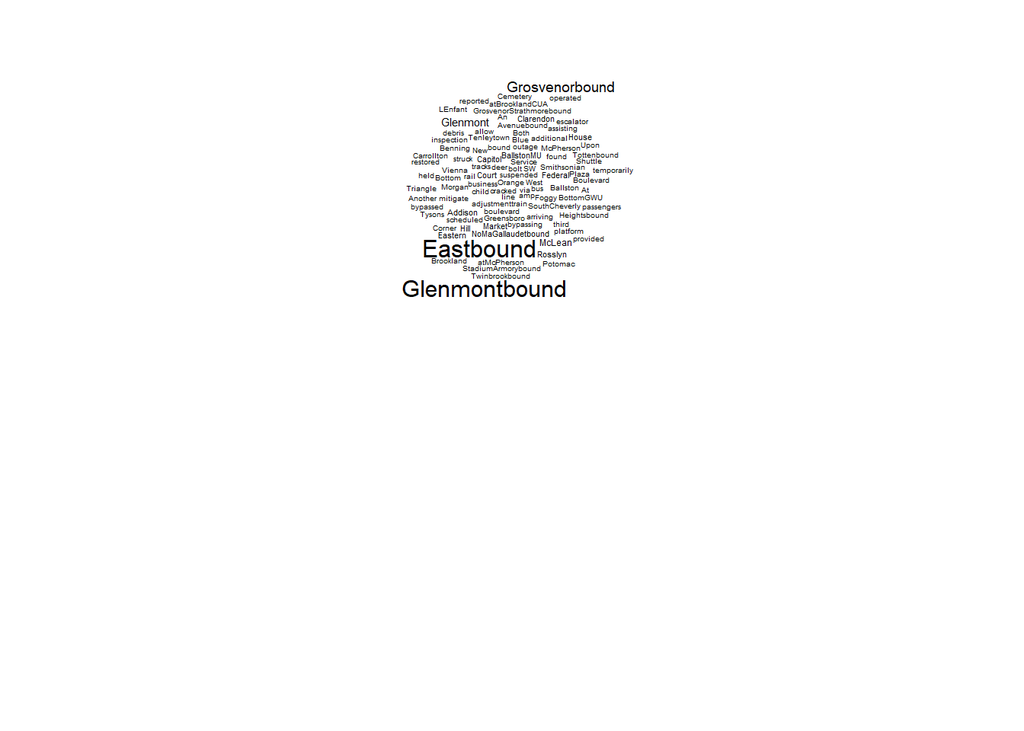

```r
set.seed(123)
par(mfrow=c(2,1))
p2forwordc <- p2forwordc[order(-p2forwordc$tfidf),]
wordcloud(p2forwordc$word[2:100], p2forwordc$tfidf[2:100], rot.per = 0, c(1,.3))
head(p2forwordc[order(p2forwordc$tfidf,decreasing = TRUE), ], 40)
```

The most frequent term is “Grovebound” . The most frequent name apart from names and directionals of course is “suspended”